# Analysis of Reading Trends

For the purposes of niche blog development

Jessica Hirsch

May 9, 2022

As the founder and sole contributor to a literature and lifestyle blog, LitGirlsRead, what began as a fun quarantine project quickly proved to be overwhelming. The desire to get something out of my work and monetize the blog was increasing, as my ability to read and write on pace waned. Ultimately reading is not nearly niche enough to truly launch into the world of blogging, let alone blogging for profit. To make a more informed decision about the next steps for LitGirls I need to analyze the market, current trends and potential customer bases. This need led me to retrieve some data off of Goodreads.com, in the form of a 10K book data set, to try and understand some reader trends and to perform a preliminary analysis on the one user who’s library was fully available, my own!

### Goodreads Analysis

At first look show us that the most popular book on Goodreads is **The Hunger Games (The Hunger Games, #1)** based on the number of people rating the book on the site. **Harry Potter and the Sorcerer’s Stone (Harry Potter, #1)**, is unsurprisingly the second most popular book.

### Preliminary Distributions

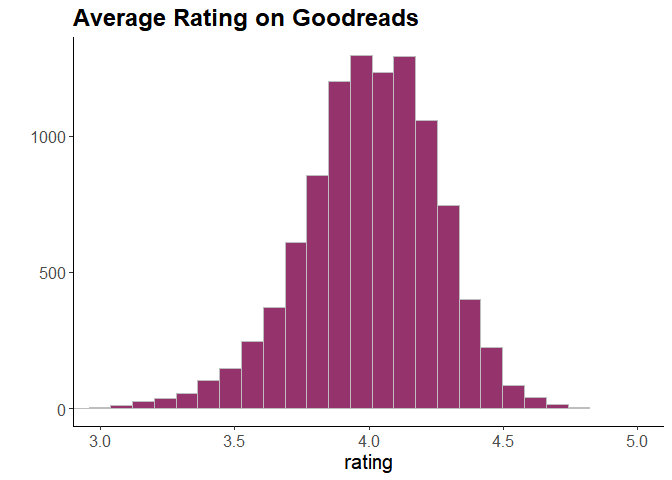

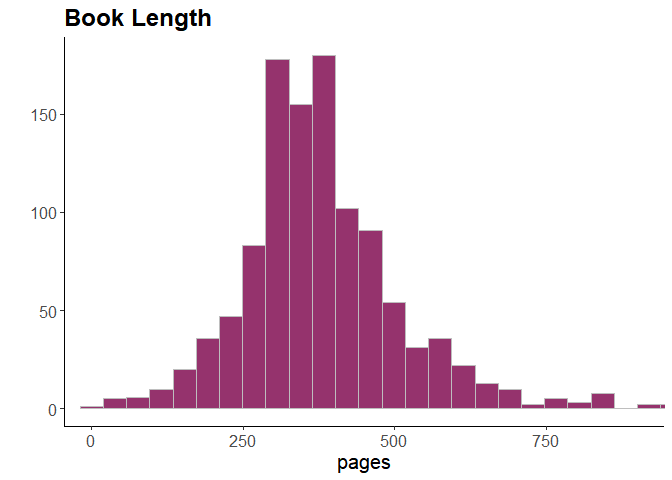

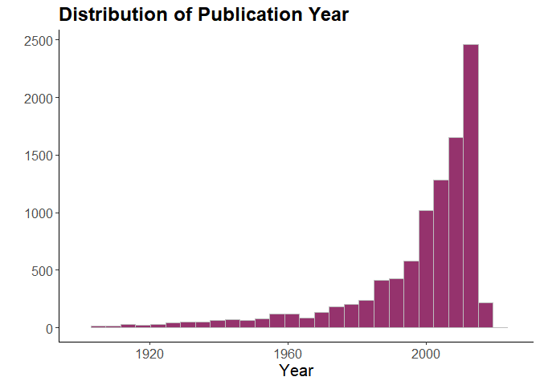

Looking over this information I can get a preliminary picture of the average reader. The average book length is 383 pages, with 4 being the median average rating. this confirms my assumption that people are more likely to rate books they like and skew their rating more generously than yelp reviewers.additionally I can see that the majority of books read (or at least rated on Goodreads) were published in this century. This is not surprising as Goodreads first launched in 2007. A fair assumptions to make here, based on my own habits, is that users are generally tracking, rating, and reviewing the books they are currently and want to read rather than going back to add in all the books read during the 1997 summer reading challenge.

### Bookshelf Breakdown

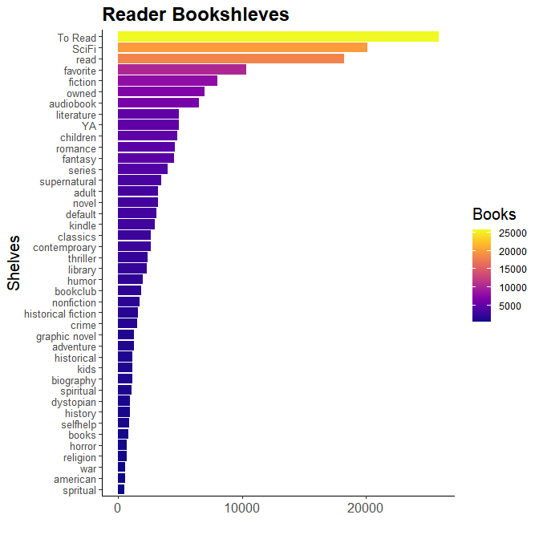

Since the Goodreads API did not supply static genre fields I took a look at the tags members used to “shelve” their reads. books may be on more than one shelf and as we can see, most of the books have yet to be read. a common problem with bibliophiles is that the rate of adding books to your To Be Read (TBR) shelf greatly outpaces the rate at which we read. there are some imperfection with this data, but looking through here for genres, we can see that SciFi, YA, romance, and fantasy are high on the list. lists like this might help me to gain some insight into how to further narrow my niche, or perhaps to focus on those hoping to diversify their reading material. What would be the most helpful is to dig into individual reader behavior. Since I do not have access to individual user data from Goodreads I will have to make due with analyzing my own habit first.

### Unique Reader Analysis

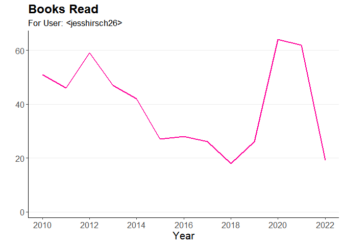

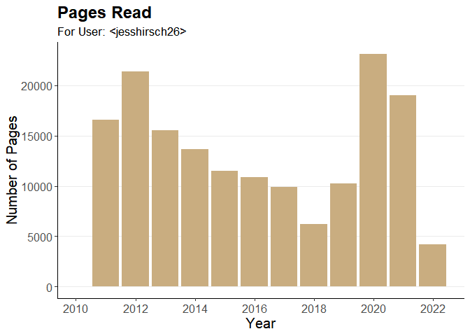

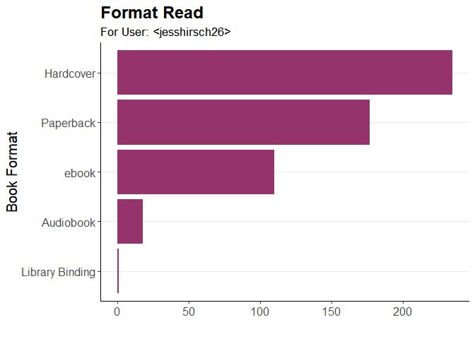

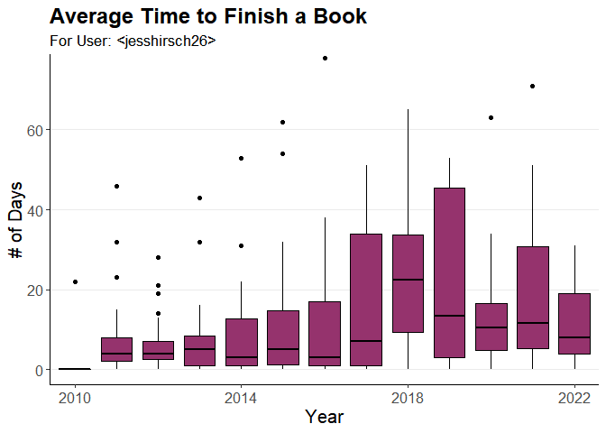

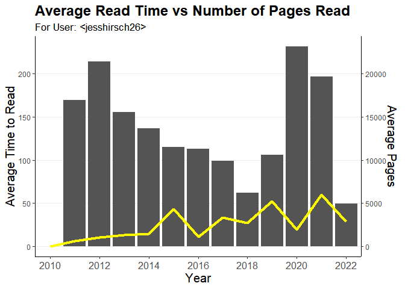

To get a better sense of reading habits I looked at how the time to read changed over time. It might seem logical that average time to read would track as an inverse of books read. in years where less books were read it presumable took longer to reach each one. however, it may have been that there were long stretches of time without reading, either between books or where the book was simply put down for months. an interesting lens would be to look at the relationship between average number of pages read and time to read. longer books, take longer to read. what we see is that there is sometimes a correlation (2020-21), but early on in 2011-14, the time to read is not nearly as volatile, and while the number of pages remained the same 2015-16, 2016 yielded more efficient reading.

Looking at my own data is certainly interesting and a good place to start. However, for a deeper analysis I would like to look at is other user data. it would be beneficial to analyze overall interest and purchasing trends across different demographic groups. This is what would help to identify a target audience (other than my parents). It would be easier to determine which reviews to write and what site to monetize through with some better user data.